# HW2

Max Moro

September 4, 2018

# Question 1

(20 points) Put the following questions into RMarkdown as headers (or subheaders if you’re making question numbers headings). Be sure to answer the questions underneath each header

## What is a basic workflow for reproducible research?

The stages of reproducible research should include:

- Data gathering
- Data analysis
- Results presentation

## What are five practical tips for making research reproducible?

The five tips for making research reproducible are:

- Document everything.
- Everything is a text file.
- All files should be human readable.
- Explicitly tie your files together.
- Have a plan to organize, store, and make your files available.

## Give an example of how you might implement each tip.

### Document Everything

I Usually write down a document, often in Markdown and SQL as comments, tracking all the steps I did to gather, transform, analyze, and display the data. When I create many versions of the same file, I use GitHub comments to track what I’ve done.

### Everything is a text file.

I use markdown, SQL files, and notes in TXT format to track what I’m doing. I’m avoiding proprietary formats like DOC or One Note to avoid issues on reading these data.

### All files should be human readable.

The code and markdown files, have an introduction paragraph that explain what is the file about, what is the objective, and the approach used.

### Have a plan to organize, store, and make your files available.

I normally use **GitHub** and **Jira** to organize my projects. With Jira I take note of the objective of the project, the different tasks and deliverables. With GitHub I can track the different changes I did. If need to re-work an old project, I *branch* the project so I can document what I’m doing for future reference.

A good practice is to create *source files* and *R-packages* that perform specific tasks, so I and others can reuse for other projects. The source code is also more readable when is broken in its major elements.

### Which one of these do you think will be the most difficult?

I think the most challenging is documenting the code in a way that my future-self or others can easily understand what the code is doing. I often assume the code is obvious, but without the knowledge of the specific project, is often very difficult to interpret the code.

# Question 2

(20 points) Download and complete “air_hist.R” code from the Files Tab on 2DS. You will build scatter plots using the plot function.

## TODO - 2a

As described in the “TODO Assignment 2: Question 2a” comment, complete the plot function regarding monthly temperature.

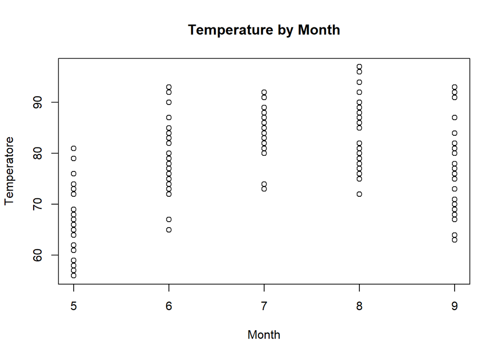

```r
# Take only Temp columns
Temperature <- airquality$Temp
# TODO: Assignment 2, Q2A: Complete the following code to yield a scatterplot with x as Month and y as Temp
# You're going to customize your plot slightly.  Use the help function to assist you if needed.
# Make the x label "Month" and the y label "Temperature"
# Finally, make the title of the plot "Temperature by Month"
plot(x=airquality$Month, y=Temperature, xlab='Month',ylab='Temperatore',main="Temperature by Month" )
```

## TODO - 2b

[figure not shown]

```r
# TODO: Assignment 2, Q2B: Build a scatter plot with x as Temperature and y as Ozone
# Complete the following code:
# Make the x label "Temperature" and the y label "Ozone",
# Make the title of the plot "Temperature vs Ozone"
plot(x=airquality$Temp, y=airquality$Month,xlab='Temperature',ylab='Ozone',main="Temperature vs Ozone")
```

## Translate

Translate these to RMarkdown and put them in your overall homework RMarkdown file.

**Done !**

# Question 3

(20 points) Download and complete “knit_cars.Rmd” in the Files tab on 2DS.

```r
summary(pressure)
```

```
##   temperature     pressure
##  Min.   :  0   Min.   :  0.0002
##  1st Qu.: 90   1st Qu.:  0.1800
##  Median :180   Median :  8.8000
##  Mean   :180   Mean   :124.3367
##  3rd Qu.:270   3rd Qu.:126.5000
##  Max.   :360   Max.   :806.0000
```

## TODO - 3A

You can also embed plots as default, for example:

TODO: Assignment 2: 3A, complete the following scatter plot. The x axis is pressure, while the y axis is temperature Please title the graph “Temperature vs Pressure”

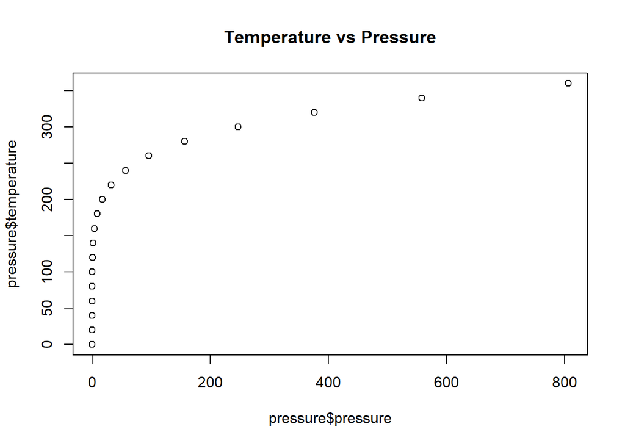

## TODO - 3B

Now flip it!

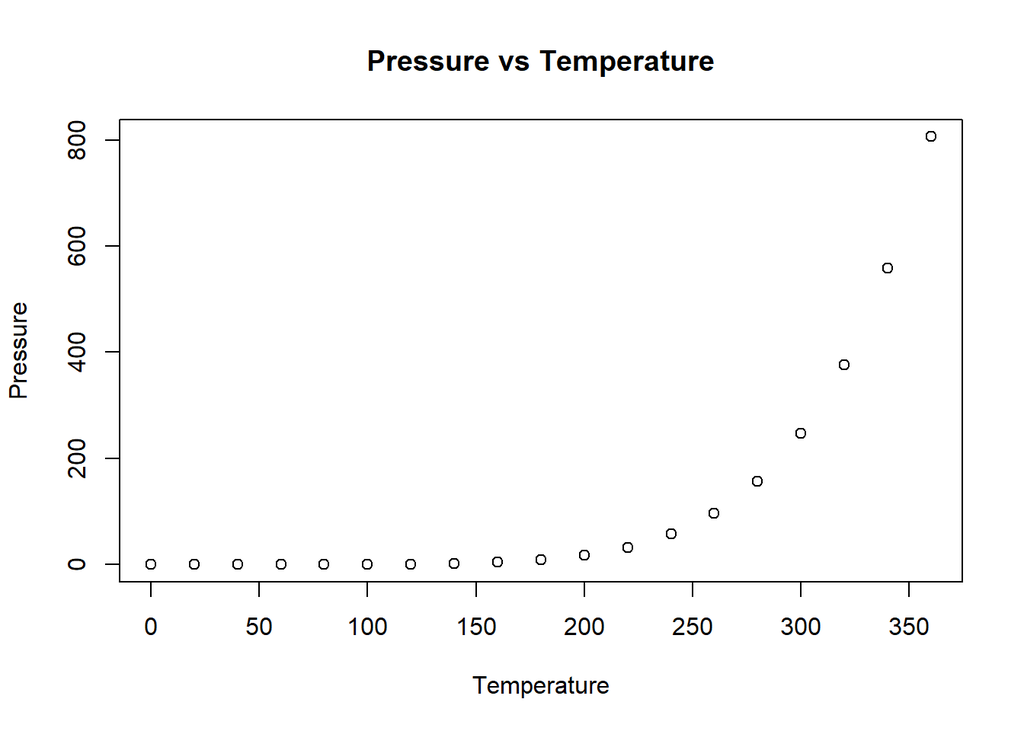